# Factor Analysis and Multidimensional Scaling

Liam Abbott

### Summary

The wine dataset contains 13 different chemical composition measurements for 180 wines. In this analysis, we use factor analysis and multidimensional scaling to reduce the dimensionality of the dataset and assess the quality-of-fit of these lower-dimensional representations.

The multidimensional scaling approach results in a model containing just two dimensions, while the factor analysis approach results in a model containing six different factors. Compare these to the five components used in a previous principal components analysis of this dataset.

### Factor Analysis

Before beginning factor analysis, look at the correlation matrix of the variables in the wine dataset:

|  | 1 | 2 | 3 | 4 | 5 | 6 | 7 | 8 | 9 | 10 | 11 | 12 | 13 |
| --- | --- | --- | --- | --- | --- | --- | --- | --- | --- | --- | --- | --- | --- |
| Alcohol.content | 1.00 |  |  |  |  |  |  |  |  |  |  |  |  |
| Malic.acid | 0.09 | 1.00 |  |  |  |  |  |  |  |  |  |  |  |
| As | 0.21 | 0.16 | 1.00 |  |  |  |  |  |  |  |  |  |  |
| Alcalinity.in.ash | -0.31 | 0.29 | 0.44 | 1.00 |  |  |  |  |  |  |  |  |  |
| Magnesium | 0.27 | -0.06 | 0.29 | -0.08 | 1.00 |  |  |  |  |  |  |  |  |
| Total.phenols | 0.30 | -0.34 | 0.13 | -0.32 | 0.22 | 1.00 |  |  |  |  |  |  |  |
| Falavanoids | 0.24 | -0.41 | 0.12 | -0.35 | 0.20 | 0.87 | 1.00 |  |  |  |  |  |  |
| Nonflavanoid.phenols | -0.16 | 0.29 | 0.18 | 0.36 | -0.26 | -0.45 | -0.54 | 1.00 |  |  |  |  |  |
| Proantocyanins | 0.15 | -0.22 | 0.01 | -0.19 | 0.24 | 0.62 | 0.66 | -0.37 | 1.00 |  |  |  |  |
| Color.Intensity | 0.53 | 0.25 | 0.25 | 0.02 | 0.19 | -0.07 | -0.19 | 0.15 | -0.05 | 1.00 |  |  |  |
| Hue | -0.06 | -0.56 | -0.07 | -0.27 | 0.07 | 0.45 | 0.55 | -0.27 | 0.31 | -0.53 | 1.00 |  |  |
| OD280.OD315 | 0.08 | -0.37 | 0.01 | -0.27 | 0.07 | 0.71 | 0.79 | -0.51 | 0.53 | -0.44 | 0.57 | 1.00 |  |
| Proline | 0.64 | -0.19 | 0.22 | -0.44 | 0.40 | 0.50 | 0.50 | -0.32 | 0.34 | 0.30 | 0.25 | 0.32 | 1.00 |

For convenience, the column names in the correlation matrix above have been compressed (1 = Alcohol, 2 = Malic acid, etc.). While some of the correlations are weak, it seems that there are enough strong correlations between variables to make factor analysis a reasonable undertaking.

The first step is to decide how many factors should be included in the model. Assuming normality, we can do this by looking at the likelihood ratio statistic for models fit with different numbers of factors. In the previous principal components analysis of the wine dataset, 5 principal components were included in the analysis based on the variance explained by each component.

Looking at the scree plot below, it seems reasonable to use 5 factors as a starting point here:

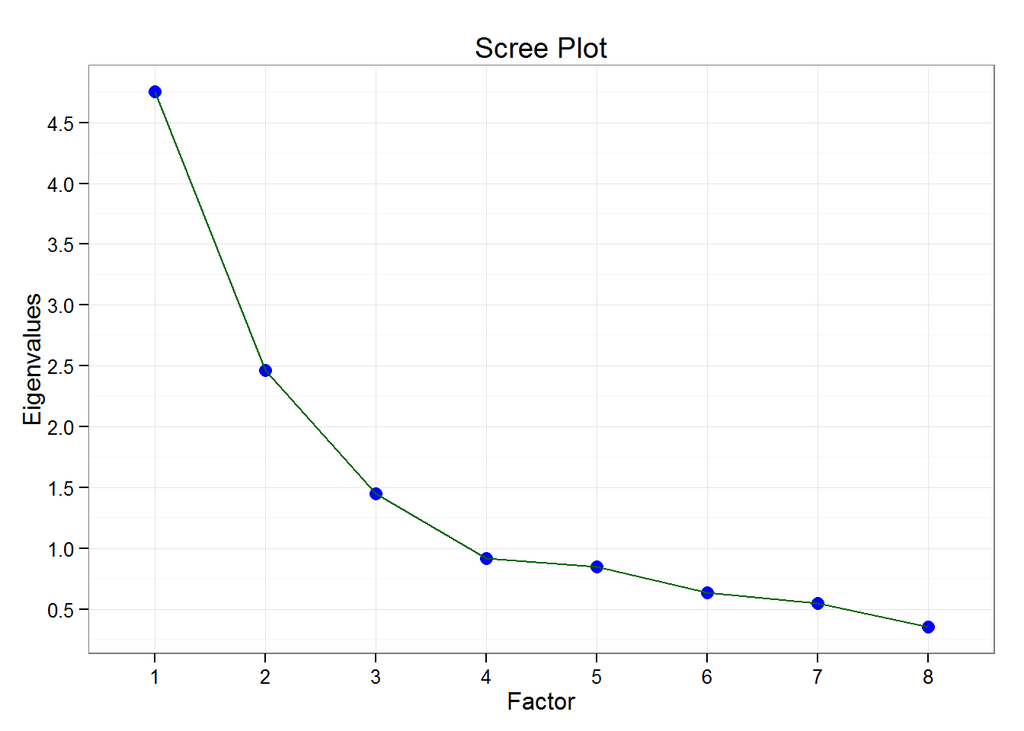

Fitting a factor analysis model with 5 factors to the wine dataset results in a model with a likelihood ratio statistic of 39.75 on 23 degrees of freedom. The p-value of 0.0164 indicates that the model with only 5 factors is perhaps a bit too restrictive.

A factor analysis model with 6 factors included results in a likelihood ratio statistic of 17.79 on 15 degrees of freedom. The p-value of 0.274 indicates that this model fits the dataset fairly well. The variable loadings for each of the six factors are shown below:

|  | Factor 1 | Factor 2 | Factor 3 | Factor 4 | Factor 5 | Factor 6 |
| --- | --- | --- | --- | --- | --- | --- |
| Alcohol.content | 0.15 | 0.75 | 0.04 | 0.26 | 0.11 | 0.09 |
| Malic.acid | -0.25 | -0.00 | 0.13 | 0.11 | 0.83 | -0.02 |
| As | 0.05 | 0.18 | 0.97 | 0.06 | 0.06 | 0.14 |
| Alcalinity.in.ash | -0.23 | -0.46 | 0.54 | 0.09 | 0.18 | -0.02 |
| Magnesium | 0.15 | 0.20 | 0.11 | 0.06 | -0.02 | 0.96 |
| Total.phenols | 0.84 | 0.25 | 0.05 | -0.04 | -0.15 | 0.04 |
| Falavanoids | 0.91 | 0.22 | 0.05 | -0.14 | -0.21 | 0.02 |
| Nonflavanoid.phenols | -0.52 | -0.14 | 0.26 | 0.11 | 0.12 | -0.20 |
| Proantocyanins | 0.70 | 0.06 | -0.05 | 0.04 | -0.06 | 0.13 |
| Color.Intensity | -0.15 | 0.40 | 0.12 | 0.88 | 0.12 | 0.07 |
| Hue | 0.40 | 0.08 | -0.05 | -0.50 | -0.48 | 0.01 |
| OD280.OD315 | 0.75 | 0.10 | -0.01 | -0.39 | -0.16 | -0.04 |
| Proline | 0.33 | 0.77 | 0.05 | 0.04 | -0.14 | 0.19 |

The loadings in the table above are from the factor analysis model using the varimax rotation. As is clear from the loadings, for this dataset the varimax rotation does not make an interpretation of the factors easy, as each factor draws on many of the variables fairly significantly.

To help interpret the loadings, we can fit another factor analysis model with the promax rotation to get the following loadings:

|  | Factor 1 | Factor 2 | Factor 3 | Factor 4 | Factor 5 | Factor 6 |
| --- | --- | --- | --- | --- | --- | --- |
| Alcohol.content | 0.03 | 0.80 | 0.22 | 0.08 | 0.18 | -0.03 |
| Malic.acid | -0.02 | 0.10 | -0.18 | 0.02 | 0.99 | -0.00 |
| As | 0.12 | 0.19 | -0.00 | 1.01 | 0.00 | 0.06 |
| Alcalinity.in.ash | 0.03 | -0.51 | 0.07 | 0.47 | 0.05 | 0.02 |
| Magnesium | -0.12 | 0.04 | -0.03 | 0.07 | -0.00 | 1.02 |
| Total.phenols | 0.92 | 0.07 | 0.11 | 0.07 | -0.01 | -0.05 |
| Falavanoids | 0.96 | 0.05 | 0.02 | 0.09 | -0.05 | -0.07 |
| Nonflavanoid.phenols | -0.44 | -0.02 | 0.05 | 0.25 | -0.02 | -0.19 |
| Proantocyanins | 0.83 | -0.16 | 0.18 | -0.09 | 0.03 | 0.09 |
| Color.Intensity | 0.03 | 0.24 | 1.04 | 0.01 | -0.15 | -0.03 |
| Hue | 0.15 | 0.11 | -0.43 | 0.09 | -0.36 | -0.00 |
| OD280.OD315 | 0.74 | 0.03 | -0.33 | 0.06 | 0.07 | -0.09 |
| Proline | 0.07 | 0.81 | 0.04 | 0.15 | -0.05 | 0.07 |

Very roughly, it seems that each factor is drawing on these variables for the most part:

|  | Factor 1 | Factor 2 | Factor 3 | Factor 4 | Factor 5 | Factor 6 |
| --- | --- | --- | --- | --- | --- | --- |
| Alcohol.content |  | x | x |  |  |  |
| Malic.acid |  |  |  |  | x |  |
| As |  |  |  | x |  |  |
| Alcalinity.in.ash |  | x |  | x |  |  |
| Magnesium |  |  |  |  |  | x |
| Total.phenols | x |  |  |  |  |  |
| Falavanoids | x |  |  |  |  |  |
| Nonflavanoid.phenols | x |  |  | x |  |  |
| Proantocyanins | x |  |  |  |  |  |
| Color.Intensity |  | x | x |  |  |  |
| Hue |  |  | x |  | x |  |
| OD280.OD315 | x |  | x |  |  |  |
| Proline |  | x |  |  |  |  |

[output not shown]

We can visualize the information in the chart by graphing the variance explained versus the factors:

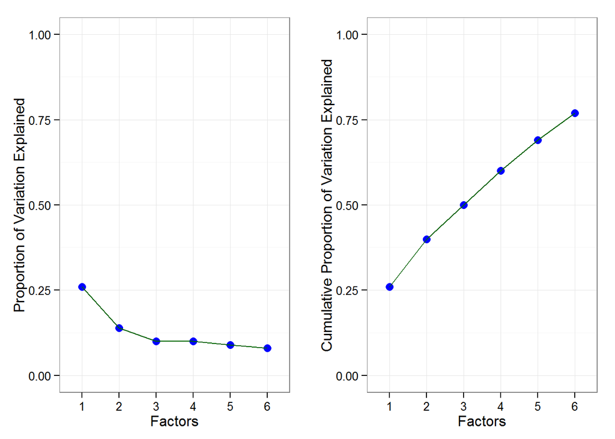

### Multidimensional Scaling

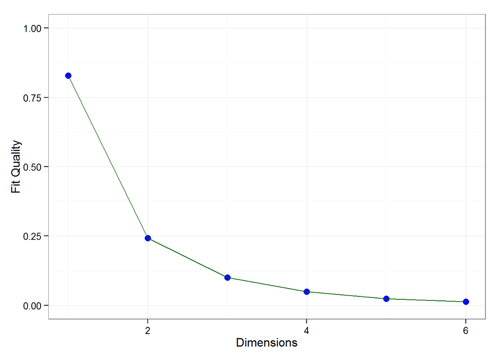

While the quality of fit measure for 6 dimensions is an excellent 0.013 (lower the better in this case), it appears that just 2 dimensions is also adequate and has the advantage of being more easily visualized, as seen in the 2-dimensional representation of the wine dataset below:

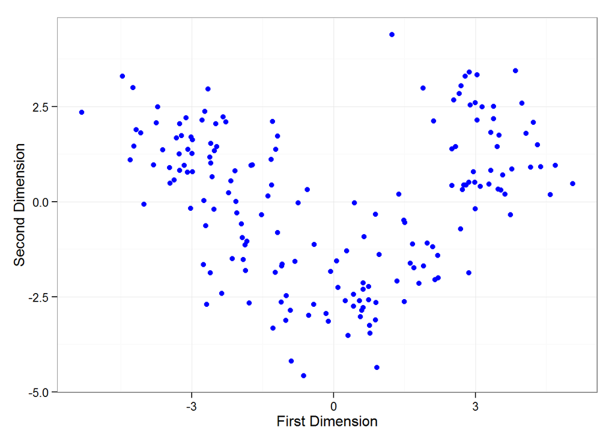